# “二手车交易价格预测项目”最终报告

## 小组成员：

### 宋昊霖（3120191040）

### 刘聪聪（3220190840）

### 李泽宁（3220190835）

### 曹健（3120190978）

### 张博（3220190916）

## 1. 问题背景及分析

### 1.1 问题背景

随着人们生活水平的提高，越来越多的人会选择购买轿车。购买二手车的人也增长迅速，各种各样的二手车交易平台（瓜子二手车，人人车等）也应运而生。由于购买轿车对于大多数普通人来说是一笔很大的支出，所以二手车的价格是一个很重要的考量，怎样根据车辆状况买到价格合适的轿车也是很多人关心的问题。

### 1.2 项目分析及数据集说明

本项目以利用来自某交易平台的二手车交易记录来预测二手车的交易价格为任务。所采用数据集总数据量超过40w，包含31列变量信息，其中15列为匿名变量。从中抽取出15万条作为训练集，5万条作为测试集A，5万条作为测试集B，同时对name、model、brand和regionCode等敏感信息进行脱敏。

### 1.3 数据集属性说明

| Field | Description |
| --- | --- |
| SaleID | 交易ID，唯一编码 |
| name | 汽车交易名称，已脱敏 |
| regDate | 汽车注册日期 |
| model | 车型编码，已脱敏 |
| brand | 汽车品牌，已脱敏 |
| bodyType | 车身类型 |
| fuelType | 燃油类型 |
| gearbox | 变速箱 |
| power | 发动机功率 |
| kilometer | 汽车已行驶公里 |
| notRepairedDamage | 汽车有尚未修复的损坏 |
| regionCode | 地区编码，已脱敏 |
| seller | 销售方 |
| offerType | 报价类型 |
| creatDate | 汽车上线时间 |
| price | 二手车交易价格（预测目标） |
| v系列特征 | 匿名特征，包含v0-14在内15个匿名特征 |

## 2. 问题描述

### 2.1 数据准备

对数据集进行缺失值处理等预处理，并对数据集进行分析（数据总览，分布情况等）及可视化。

### 2.2 准备采用的方法或模型

此问题为回归问题，我们拟采用两种不同的算法（如线性回归模型，决策树等）对其进行预测，并对预测结果进行对比。

### 2.3 预期的挖掘结果

利用数据集中的不同属性建立模型并利用模型实现对测试集数据中二手车价格的预测。

### 2.4 项目评估指标

本项目最后采用MAE(Mean Absolute Error)作为评价标准：

$$MAE = \frac{\sum_{i=1}^{n}\left | y_{i} - \hat{y}_{i}\right |}{n}$$

MAE越小，说明模型预测越准确。

### 2.5 项目分工

- 李泽宁：数据分析及预处理，文档编写
- 张博：算法1实现及分析，文档编写
- 刘聪聪：算法2实现及分析，文档编写
- 宋昊霖: 数据可视化，文档编写
- 曹健: 文档整合与编写

## 3. 数据分析与可视化

### 3.1 数据预处理

- ‘price’为长尾分布，对该特征进行了处理，更加符合高斯分布
- SaleID为交易ID，肯定没用，但是我们可以用来统计别的特征的group数量
- name为汽车交易名称，已经脱敏一般没什么好挖掘的，不过同名的好像不少，统计了一下同名数据个数，为name_count，然后删除了属性信息‘name’
- 'seller'、'offerType'特征严重倾斜，训练数据中'seller'有一个特殊值，删除了该样本，而且把‘seller’和‘offerType’属性删除了
- 在题目中规定了power范围为[0, 600]，对数据集中power属性进行了修正
- 'notRepairedDamage'属性中'-'应该也是空值，用nan替换
- 对于缺失值，用众数对缺失值进行了填充
- 对于时间属性信息，‘regDates’和‘creatDates’，增添了6列属性，分别为‘regDate_year’、‘regDate_month’、‘regDate_day’、‘creatDate_year’、‘creatDate_month’、‘creatDate_day’

### 3.2 数据分析及可视化过程

- 通过describe()来熟悉训练数据、测试数据数值属性的相关统计量，包括均值，方差，最小值，第1四分位数，中位数，第3四分位数，最大值。
- 通过info()来熟悉数据类型
- 通过可视化方法分析了训练数据、测试数据中的数值属性趋势
- 分析训练数据、测试数据类别特征nunique分布
- 分析训练数据、测试数据缺失值情况
- 对预测属性‘price’ 进行了相关性分析

### 3.3 数据分析代码及结果

 仓库地址：https://github.com/Zening-Li/BIT_DataMining_project

**数据集**

- 训练数据：data/used_car_train_20200313.csv
- 测试数据：data/used_car_testB_20200421.csv
- 提交数据：data/used_car_sample_submit.csv

**代码及结果展示**

```python
%matplotlib inline
import pandas as pd
import numpy as np
from datetime import datetime
import matplotlib.pyplot as plt
import seaborn as sns

import warnings

warnings.filterwarnings('ignore')
pd.set_option('display.max_columns', None)
sns.set(style='whitegrid')
plt.style.use('seaborn-darkgrid')
plt.rcParams['font.sans-serif']=['simhei']   # 用黑体显示中文
plt.rcParams['axes.unicode_minus']=False     # 正常显示负号
```

#### 3.3.1 数据读取

```python
train = pd.read_csv('./data/used_car_train_20200313.csv', sep=' ')
test = pd.read_csv('./data/used_car_testB_20200421.csv', sep=' ')
```

- SaleID - 交易ID，唯一编码
- name - 汽车交易名称
- regDate - 汽车注册时间
- model - 车型编码
- brand - 品牌
- bodyType - 车身类型
- fuelType - 燃油类型
- gearbox - 变速箱
- power - 汽车功率
- kilometer - 汽车行驶公里
- notRepairedDamage - 汽车有尚未修复的损坏
- regionCode - 地区编码
- seller - 销售方
- offerType - 报价类型
- creatDate - 广告发布时间
- price - 汽车价格
- v_0', 'v_1', ..., 'v_14' - 匿名特征，包含v0-14在内15个匿名特征

```python
# 简略查看训练数据
train.head()
```

|  | SaleID | name | regDate | model | brand | bodyType | fuelType | gearbox | power | kilometer | notRepairedDamage | regionCode | seller | offerType | creatDate | price | v_0 | v_1 | v_2 | v_3 | v_4 | v_5 | v_6 | v_7 | v_8 | v_9 | v_10 | v_11 | v_12 | … |
| --- | --- | --- | --- | --- | --- | --- | --- | --- | --- | --- | --- | --- | --- | --- | --- | --- | --- | --- | --- | --- | --- | --- | --- | --- | --- | --- | --- | --- | --- | --- |
| 0 | 0 | 736 | 20040402 | 30.0 | 6 | 1.0 | 0.0 | 0.0 | 60 | 12.5 | 0.0 | 1046 | 0 | 0 | 20160404 | 1850 | 43.357796 | 3.966344 | 0.050257 | 2.159744 | 1.143786 | 0.235676 | 0.101988 | 0.129549 | 0.022816 | 0.097462 | -2.881803 | 2.804097 | -2.420821 | … |
| 1 | 1 | 2262 | 20030301 | 40.0 | 1 | 2.0 | 0.0 | 0.0 | 0 | 15.0 | - | 4366 | 0 | 0 | 20160309 | 3600 | 45.305273 | 5.236112 | 0.137925 | 1.380657 | -1.422165 | 0.264777 | 0.121004 | 0.135731 | 0.026597 | 0.020582 | -4.900482 | 2.096338 | -1.030483 | … |
| 2 | 2 | 14874 | 20040403 | 115.0 | 15 | 1.0 | 0.0 | 0.0 | 163 | 12.5 | 0.0 | 2806 | 0 | 0 | 20160402 | 6222 | 45.978359 | 4.823792 | 1.319524 | -0.998467 | -0.996911 | 0.251410 | 0.114912 | 0.165147 | 0.062173 | 0.027075 | -4.846749 | 1.803559 | 1.565330 | … |
| 3 | 3 | 71865 | 19960908 | 109.0 | 10 | 0.0 | 0.0 | 1.0 | 193 | 15.0 | 0.0 | 434 | 0 | 0 | 20160312 | 2400 | 45.687478 | 4.492574 | -0.050616 | 0.883600 | -2.228079 | 0.274293 | 0.110300 | 0.121964 | 0.033395 | 0.000000 | -4.509599 | 1.285940 | -0.501868 | … |
| 4 | 4 | 111080 | 20120103 | 110.0 | 5 | 1.0 | 0.0 | 0.0 | 68 | 5.0 | 0.0 | 6977 | 0 | 0 | 20160313 | 5200 | 44.383511 | 2.031433 | 0.572169 | -1.571239 | 2.246088 | 0.228036 | 0.073205 | 0.091880 | 0.078819 | 0.121534 | -1.896240 | 0.910783 | 0.931110 | … |

数值属性有发动机功率power，汽车已经行驶公里kilometer，二手车交易价格price以及15个匿名特征，而标称属性有汽车交易名称、车型编码、品牌、车身类型、燃油类型、变速箱、汽车有尚未修复损坏、地区编码、销售方、报价类型

```python
train.shape
```

```
(150000, 31)
```

```python
# 简略查看测试数据
test.head()
```

|  | SaleID | name | regDate | model | brand | bodyType | fuelType | gearbox | power | kilometer | notRepairedDamage | regionCode | seller | offerType | creatDate | v_0 | v_1 | v_2 | v_3 | v_4 | v_5 | v_6 | v_7 | v_8 | v_9 | v_10 | v_11 | v_12 | v_13 | … |
| --- | --- | --- | --- | --- | --- | --- | --- | --- | --- | --- | --- | --- | --- | --- | --- | --- | --- | --- | --- | --- | --- | --- | --- | --- | --- | --- | --- | --- | --- | --- |
| 0 | 200000 | 133777 | 20000501 | 67.0 | 0 | 1.0 | 0.0 | 0.0 | 101 | 15.0 | 0.0 | 5019 | 0 | 0 | 20160308 | 42.142061 | -3.094739 | -0.721300 | 1.466344 | 1.009846 | 0.236520 | 0.000241 | 0.105319 | 0.046233 | 0.094522 | 3.619512 | -0.280607 | -2.019761 | 0.978828 | … |
| 1 | 200001 | 61206 | 19950211 | 19.0 | 6 | 2.0 | 0.0 | 0.0 | 73 | 6.0 | 0.0 | 1505 | 0 | 0 | 20160310 | 43.907034 | -3.244605 | -0.766430 | 1.276718 | -1.065338 | 0.261518 | 0.000000 | 0.120323 | 0.046784 | 0.035385 | 2.997376 | -1.406705 | -1.020884 | -1.349990 | … |
| 2 | 200002 | 67829 | 20090606 | 5.0 | 5 | 4.0 | 0.0 | 0.0 | 120 | 5.0 | - | 1776 | 0 | 0 | 20160309 | 45.389665 | 3.372384 | -0.965565 | -2.447316 | 0.624268 | 0.261691 | 0.090836 | 0.000000 | 0.079655 | 0.073586 | -3.951084 | -0.433467 | 0.918964 | 1.634604 | … |
| 3 | 200003 | 8892 | 20020601 | 22.0 | 9 | 1.0 | 0.0 | 0.0 | 58 | 15.0 | 0.0 | 26 | 0 | 0 | 20160314 | 42.788775 | 4.035052 | -0.217403 | 1.708806 | 1.119165 | 0.236050 | 0.101777 | 0.098950 | 0.026830 | 0.096614 | -2.846788 | 2.800267 | -2.524610 | 1.076819 | … |
| 4 | 200004 | 76998 | 20030301 | 46.0 | 6 | 0.0 | NaN | 0.0 | 116 | 15.0 | 0.0 | 738 | 0 | 0 | 20160306 | 43.670763 | -3.135382 | -1.134107 | 0.470315 | 0.134032 | 0.257000 | 0.000000 | 0.066732 | 0.057771 | 0.068852 | 2.839010 | -1.659801 | -0.924142 | 0.199423 | … |

```python
test.shape
```

```
(50000, 30)
```

#### 3.3.2 数据分析

#### (1)数值属性分析

```python
# 通过describe()来熟悉训练数据数值属性的相关统计量
train_numeric_features = [
    'power', 'kilometer', 'price', 'v_0', 'v_1', 'v_2', 'v_3', 'v_4', 'v_5', 'v_6',
    'v_7', 'v_8', 'v_9', 'v_10', 'v_11', 'v_12', 'v_13', 'v_14'
]
train[train_numeric_features].describe()
```

|  | power | kilometer | price | v_0 | v_1 | v_2 | v_3 | v_4 | v_5 | v_6 | v_7 | v_8 | v_9 | v_10 | v_11 | v_12 | v_13 | v_14 |
| --- | --- | --- | --- | --- | --- | --- | --- | --- | --- | --- | --- | --- | --- | --- | --- | --- | --- | --- |
| count | 150000.000000 | 150000.000000 | 150000.000000 | 150000.000000 | 150000.000000 | 150000.000000 | 150000.000000 | 150000.000000 | 150000.000000 | 150000.000000 | 150000.000000 | 150000.000000 | 150000.000000 | 150000.000000 | 150000.000000 | 150000.000000 | 150000.000000 | 150000.000000 |
| mean | 119.316547 | 12.597160 | 5923.327333 | 44.406268 | -0.044809 | 0.080765 | 0.078833 | 0.017875 | 0.248204 | 0.044923 | 0.124692 | 0.058144 | 0.061996 | -0.001000 | 0.009035 | 0.004813 | 0.000313 | -0.000688 |
| std | 177.168419 | 3.919576 | 7501.998477 | 2.457548 | 3.641893 | 2.929618 | 2.026514 | 1.193661 | 0.045804 | 0.051743 | 0.201410 | 0.029186 | 0.035692 | 3.772386 | 3.286071 | 2.517478 | 1.288988 | 1.038685 |
| min | 0.000000 | 0.500000 | 11.000000 | 30.451976 | -4.295589 | -4.470671 | -7.275037 | -4.364565 | 0.000000 | 0.000000 | 0.000000 | 0.000000 | 0.000000 | -9.168192 | -5.558207 | -9.639552 | -4.153899 | -6.546556 |
| 25% | 75.000000 | 12.500000 | 1300.000000 | 43.135799 | -3.192349 | -0.970671 | -1.462580 | -0.921191 | 0.243615 | 0.000038 | 0.062474 | 0.035334 | 0.033930 | -3.722303 | -1.951543 | -1.871846 | -1.057789 | -0.437034 |
| 50% | 110.000000 | 15.000000 | 3250.000000 | 44.610266 | -3.052671 | -0.382947 | 0.099722 | -0.075910 | 0.257798 | 0.000812 | 0.095866 | 0.057014 | 0.058484 | 1.624076 | -0.358053 | -0.130753 | -0.036245 | 0.141246 |
| 75% | 150.000000 | 15.000000 | 7700.000000 | 46.004721 | 4.000670 | 0.241335 | 1.565838 | 0.868758 | 0.265297 | 0.102009 | 0.125243 | 0.079382 | 0.087491 | 2.844357 | 1.255022 | 1.776933 | 0.942813 | 0.680378 |
| max | 19312.000000 | 15.000000 | 99999.000000 | 52.304178 | 7.320308 | 19.035496 | 9.854702 | 6.829352 | 0.291838 | 0.151420 | 1.404936 | 0.160791 | 0.222787 | 12.357011 | 18.819042 | 13.847792 | 11.147669 | 8.658418 |

```python
# 通过describe()来熟悉测试数据数值属性的相关统计量
test_numeric_features = [
    'power', 'kilometer', 'v_0', 'v_1', 'v_2', 'v_3', 'v_4', 'v_5', 'v_6',
    'v_7', 'v_8', 'v_9', 'v_10', 'v_11', 'v_12', 'v_13', 'v_14'
]
test[test_numeric_features].describe()
```

|  | power | kilometer | v_0 | v_1 | v_2 | v_3 | v_4 | v_5 | v_6 | v_7 | v_8 | v_9 | v_10 | v_11 | v_12 | v_13 | v_14 |
| --- | --- | --- | --- | --- | --- | --- | --- | --- | --- | --- | --- | --- | --- | --- | --- | --- | --- |
| count | 50000.000000 | 50000.000000 | 50000.000000 | 50000.000000 | 50000.000000 | 50000.000000 | 50000.000000 | 50000.000000 | 50000.000000 | 50000.000000 | 50000.000000 | 50000.000000 | 50000.000000 | 50000.000000 | 50000.000000 | 50000.000000 | 50000.000000 |
| mean | 119.766960 | 12.598260 | 44.400023 | -0.065525 | 0.079706 | 0.078381 | 0.022361 | 0.248147 | 0.044624 | 0.124693 | 0.058198 | 0.062113 | 0.019633 | 0.002759 | 0.004342 | 0.004570 | -0.007209 |
| std | 206.313348 | 3.912519 | 2.459920 | 3.636631 | 2.930829 | 2.019136 | 1.194215 | 0.045836 | 0.051664 | 0.201440 | 0.029171 | 0.035723 | 3.764095 | 3.289523 | 2.515912 | 1.287194 | 1.044718 |
| min | 0.000000 | 0.500000 | 31.122325 | -4.231855 | -4.032142 | -5.801254 | -4.233626 | 0.000000 | 0.000000 | 0.000000 | 0.000000 | 0.000000 | -9.119719 | -5.662163 | -8.291868 | -4.157649 | -6.098192 |
| 25% | 75.000000 | 12.500000 | 43.120935 | -3.193169 | -0.967832 | -1.456793 | -0.922153 | 0.243436 | 0.000035 | 0.062519 | 0.035413 | 0.033880 | -3.675196 | -1.963928 | -1.865406 | -1.048722 | -0.440706 |
| 50% | 110.000000 | 15.000000 | 44.601493 | -3.053506 | -0.384910 | 0.118448 | -0.068187 | 0.257818 | 0.000801 | 0.095880 | 0.056804 | 0.058749 | 1.632134 | -0.375537 | -0.138943 | -0.036352 | 0.136849 |
| 75% | 150.000000 | 15.000000 | 45.987018 | 3.978703 | 0.239689 | 1.563490 | 0.871565 | 0.265263 | 0.101654 | 0.125470 | 0.079387 | 0.087624 | 2.846205 | 1.263451 | 1.775632 | 0.945239 | 0.685555 |
| max | 19211.000000 | 15.000000 | 51.676686 | 7.190759 | 18.865988 | 9.386558 | 4.959106 | 0.291176 | 0.153403 | 1.411559 | 0.157458 | 0.211304 | 12.177864 | 18.789496 | 13.384828 | 5.635374 | 2.649768 |

```python
# 通过info()来熟悉训练数据类型
train.info()
```

```
<class 'pandas.core.frame.DataFrame'>
RangeIndex: 150000 entries, 0 to 149999
Data columns (total 31 columns):
SaleID               150000 non-null int64
name                 150000 non-null int64
regDate              150000 non-null int64
model                149999 non-null float64
brand                150000 non-null int64
bodyType             145494 non-null float64
fuelType             141320 non-null float64
gearbox              144019 non-null float64
power                150000 non-null int64
kilometer            150000 non-null float64
notRepairedDamage    150000 non-null object
regionCode           150000 non-null int64
seller               150000 non-null int64
offerType            150000 non-null int64
creatDate            150000 non-null int64
price                150000 non-null int64
v_0                  150000 non-null float64
v_1                  150000 non-null float64
v_2                  150000 non-null float64
v_3                  150000 non-null float64
v_4                  150000 non-null float64
v_5                  150000 non-null float64
v_6                  150000 non-null float64
v_7                  150000 non-null float64
v_8                  150000 non-null float64
v_9                  150000 non-null float64
v_10                 150000 non-null float64
v_11                 150000 non-null float64
v_12                 150000 non-null float64
v_13                 150000 non-null float64
v_14                 150000 non-null float64
dtypes: float64(20), int64(10), object(1)
memory usage: 35.5+ MB
```

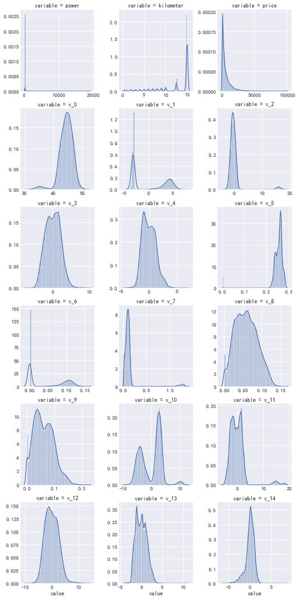

```python
# 可视化训练数据中的数值属性
f_train = pd.melt(train, value_vars=train_numeric_features)
g_train = sns.FacetGrid(f_train, col="variable",  col_wrap=3, sharex=False, sharey=False)
g_train = g_train.map(sns.distplot, "value")
plt.show()
```

'price'为长尾分布，需要对其做数据转换

'power'应该存在异常值，需要处理

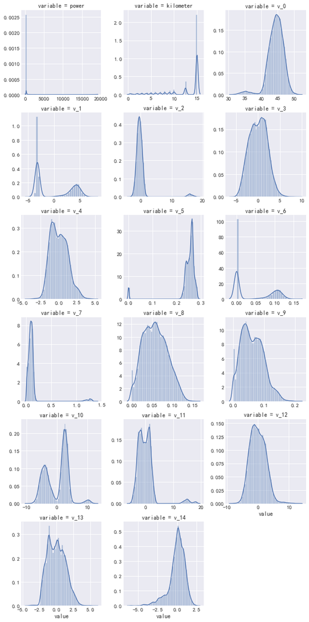

```python
# 可视化测试数据中的数值属性
f_test = pd.melt(test, value_vars=test_numeric_features)
g_test = sns.FacetGrid(f_test, col="variable",  col_wrap=3, sharex=False, sharey=False)
g_test = g_test.map(sns.distplot, "value")
plt.show()
```

#### (2) 类别属性分析

```python
# 分析训练数据类别特征nunique分布
category_features = [
    'name', 'model', 'brand', 'bodyType', 'fuelType', 'gearbox',
    'notRepairedDamage', 'regionCode', 'seller', 'offerType', 'regionCode'
]
for feature in category_features:
    print(feature + "的特征分布如下：")
    print("{}特征有个{}不同的值".format(feature, train[feature].nunique()))
    print(train[feature].value_counts())
    print(72 * '-')
```

[output not shown]

[output cut: 296 more lines]

```
8117      1
7507      1
7989      1
6505      1
6377      1
8042      1
7763      1
7786      1
6414      1
7063      1
4239      1
5931      1
7267      1
Name: regionCode, Length: 7905, dtype: int64
------------------------------------------------------------------------
```

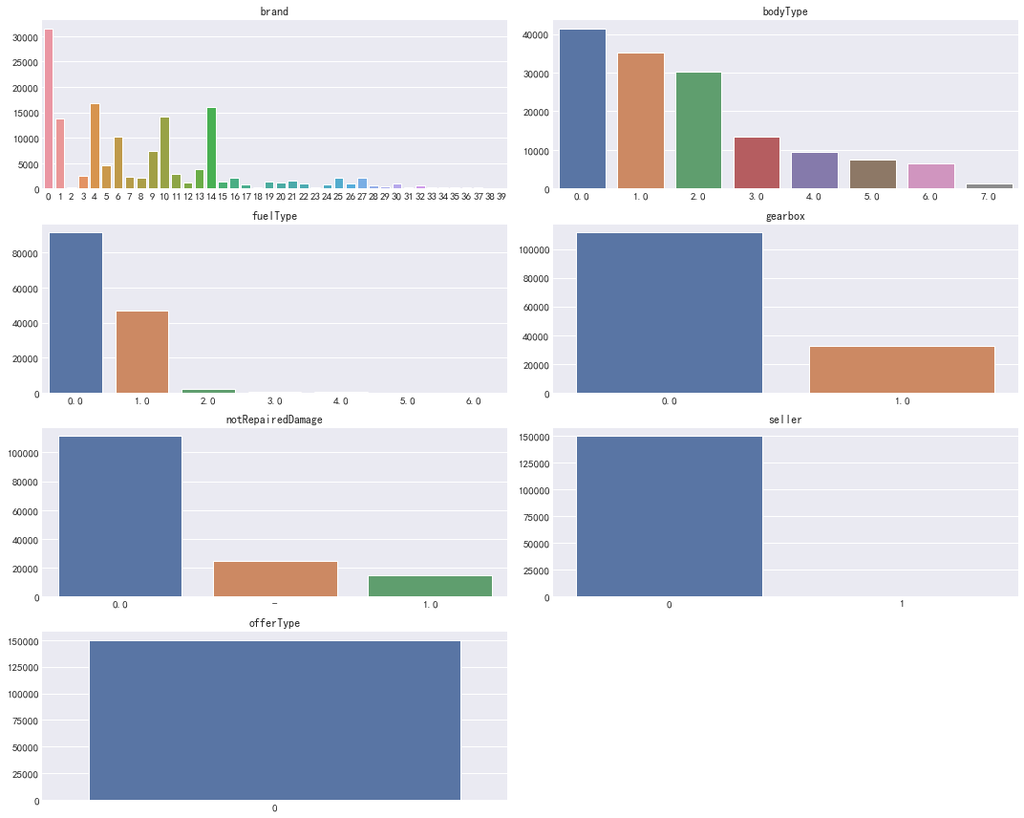

```python
# 对训练数据类别特征取值较少的，画出直方图
plt.figure(figsize=(15, 12))
i = 1
for feature in category_features:
    if train[feature].nunique() < 50:
        plt.subplot(4, 2, i)
        i += 1
        v = train[feature].value_counts()
        fig = sns.barplot(x=v.index, y=v.values)
        plt.title(feature)
plt.tight_layout()
plt.show()
```

```python
# 分析测试数据类别特征nunique分布
for feature in category_features:
    print(feature + "的特征分布如下：")
    print("{}特征有个{}不同的值".format(feature, test[feature].nunique()))
    print(test[feature].value_counts())
    print(72 * '-')
```

[output not shown]

[output cut: 295 more lines]

```
2867      1
4912      1
2771      1
6310      1
6865      1
6833      1
4656      1
6609      1
2451      1
4231      1
6513      1
6481      1
6061      1
Name: regionCode, Length: 6998, dtype: int64
------------------------------------------------------------------------
```

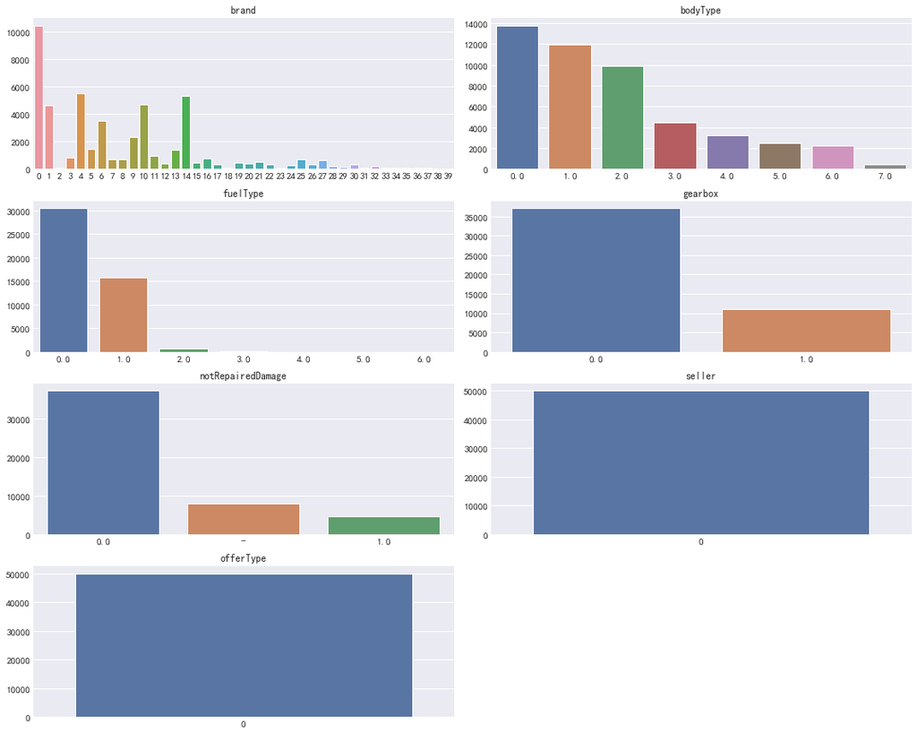

```python
# 对测试数据类别特征取值较少的，画出直方图
plt.figure(figsize=(15, 12))
i = 1
for feature in category_features:
    if test[feature].nunique() < 50:
        plt.subplot(4, 2, i)
        i += 1
        v = test[feature].value_counts()
        fig = sns.barplot(x=v.index, y=v.values)
        plt.title(feature)
plt.tight_layout()
plt.show()
```

可以发现两个类别特征严重倾斜，分别是销售方seller和报价类型offerType，上述两个特征对分析预测没有任何帮助。

另外，汽车有尚未修复的损坏notRepairedDamage有3个不同的属性值：0.0，1.0，'-'，其中'-'应该也为空值。

#### 3.3.3 数据缺失值

```python
# 'notRepairedDamage'属性中'-'应该也是空值，用nan替换
train['notRepairedDamage'].replace('-', np.nan, inplace=True)
test['notRepairedDamage'].replace('-', np.nan, inplace=True)
```

```python
# 分析训练数据缺失值
train.isnull().sum()[train.isnull().sum() > 0]
```

```
model                    1
bodyType              4506
fuelType              8680
gearbox               5981
notRepairedDamage    24324
dtype: int64
```

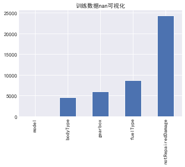

```python
# 训练数据nan可视化
train_missing = train.isnull().sum()
train_missing = train_missing[train_missing > 0]
train_missing.sort_values(inplace=True)
train_missing.plot.bar()
plt.title("训练数据nan可视化")
plt.show()
```

```python
# 分析测试数据缺失值
test.isnull().sum()[test.isnull().sum() > 0]
```

```
bodyType             1504
fuelType             2924
gearbox              1968
notRepairedDamage    8069
dtype: int64
```

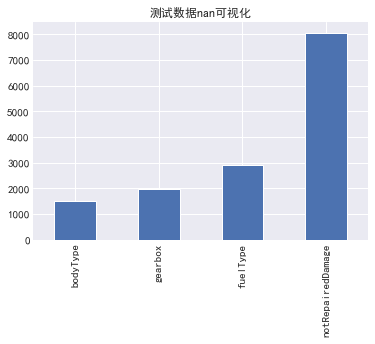

```python
# 测试数据nan可视化
test_missing = test.isnull().sum()
test_missing = test_missing[test_missing > 0]
test_missing.sort_values(inplace=True)
test_missing.plot.bar()
plt.title("测试数据nan可视化")
plt.show()
```

#### 3.3.4 相关性分析

```python
# 对'price'属性进行相关性分析
price_numeric = train[train_numeric_features]
correlation = price_numeric.corr()
print(correlation['price'].sort_values(ascending = False),'\n')
```

```
price        1.000000
v_12         0.692823
v_8          0.685798
v_0          0.628397
power        0.219834
v_5          0.164317
v_2          0.085322
v_6          0.068970
v_1          0.060914
v_14         0.035911
v_13        -0.013993
v_7         -0.053024
v_4         -0.147085
v_9         -0.206205
v_10        -0.246175
v_11        -0.275320
kilometer   -0.440519
v_3         -0.730946
Name: price, dtype: float64
```

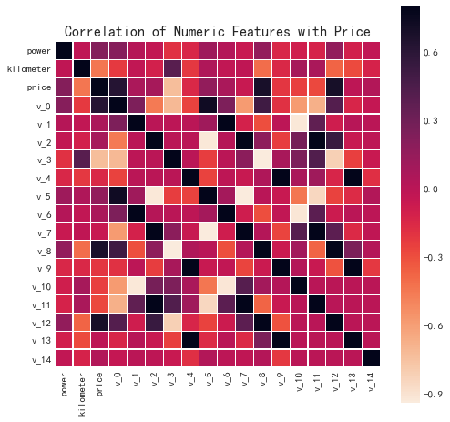

```python
f, ax = plt.subplots(figsize=(8, 8))
plt.title('Correlation of Numeric Features with Price', y=1, size=16)
sns.heatmap(correlation, square=True, vmax=0.8, linewidths=0.1, cmap=sns.cm.rocket_r)
plt.show()
```

匿名特征v_0, v_3, v_8, v_12与'price'相关性很高

### 3.4 数据预处理

- 预处理后数据： process_data/train_data_v1.csv，process_data/test_data_v1.csv

#### 3.4.1 处理目标值长尾分布

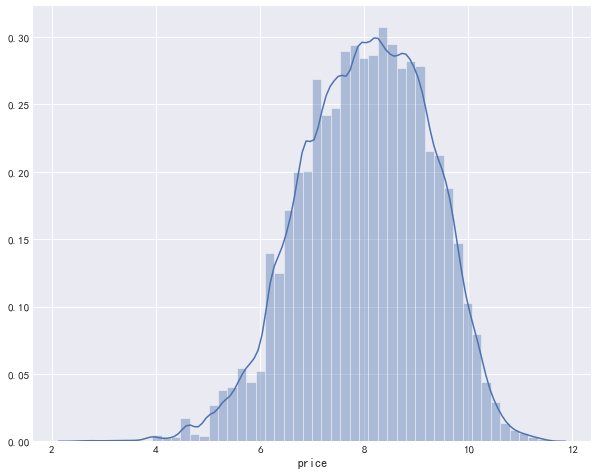

```python
# price 为长尾分布，对该特征进行处理
train['price'] = np.log1p(train['price'])

# 可视化处理后'price'分布
plt.figure(figsize=(10, 8))
sns.distplot(train['price'])
plt.show()
```

#### 3.4.2 处理无用值

```python
# 合并训练数据和测试数据，方便后续数据预处理
df = pd.concat([train, test], axis=0, ignore_index=True)
df.head()
```

|  | SaleID | bodyType | brand | creatDate | fuelType | gearbox | kilometer | model | name | notRepairedDamage | offerType | power | price | regDate | regionCode | seller | v_0 | v_1 | v_10 | v_11 | v_12 | v_13 | v_14 | v_2 | v_3 | v_4 | v_5 | v_6 | v_7 | … |
| --- | --- | --- | --- | --- | --- | --- | --- | --- | --- | --- | --- | --- | --- | --- | --- | --- | --- | --- | --- | --- | --- | --- | --- | --- | --- | --- | --- | --- | --- | --- |
| 0 | 0 | 1.0 | 6 | 20160404 | 0.0 | 0.0 | 12.5 | 30.0 | 736 | 0.0 | 0 | 60 | 7.523481 | 20040402 | 1046 | 0 | 43.357796 | 3.966344 | -2.881803 | 2.804097 | -2.420821 | 0.795292 | 0.914762 | 0.050257 | 2.159744 | 1.143786 | 0.235676 | 0.101988 | 0.129549 | … |
| 1 | 1 | 2.0 | 1 | 20160309 | 0.0 | 0.0 | 15.0 | 40.0 | 2262 | - | 0 | 0 | 8.188967 | 20030301 | 4366 | 0 | 45.305273 | 5.236112 | -4.900482 | 2.096338 | -1.030483 | -1.722674 | 0.245522 | 0.137925 | 1.380657 | -1.422165 | 0.264777 | 0.121004 | 0.135731 | … |
| 2 | 2 | 1.0 | 15 | 20160402 | 0.0 | 0.0 | 12.5 | 115.0 | 14874 | 0.0 | 0 | 163 | 8.736007 | 20040403 | 2806 | 0 | 45.978359 | 4.823792 | -4.846749 | 1.803559 | 1.565330 | -0.832687 | -0.229963 | 1.319524 | -0.998467 | -0.996911 | 0.251410 | 0.114912 | 0.165147 | … |
| 3 | 3 | 0.0 | 10 | 20160312 | 0.0 | 1.0 | 15.0 | 109.0 | 71865 | 0.0 | 0 | 193 | 7.783641 | 19960908 | 434 | 0 | 45.687478 | 4.492574 | -4.509599 | 1.285940 | -0.501868 | -2.438353 | -0.478699 | -0.050616 | 0.883600 | -2.228079 | 0.274293 | 0.110300 | 0.121964 | … |
| 4 | 4 | 1.0 | 5 | 20160313 | 0.0 | 0.0 | 5.0 | 110.0 | 111080 | 0.0 | 0 | 68 | 8.556606 | 20120103 | 6977 | 0 | 44.383511 | 2.031433 | -1.896240 | 0.910783 | 0.931110 | 2.834518 | 1.923482 | 0.572169 | -1.571239 | 2.246088 | 0.228036 | 0.073205 | 0.091880 | … |

```python
# SaleID为交易ID，肯定没用，但是我们可以用来统计别的特征的group数量
# name为汽车交易名称，已经脱敏一般没什么好挖掘的，不过同名的好像不少，可以挖掘一下
df['name_count'] = df.groupby(['name'])['SaleID'].transform('count')
df.drop(['name'], axis=1, inplace=True)
```

#### 3.4.3 处理特征严重倾斜数据

```python
# 'seller'、'offerType'特征严重倾斜，训练数据中'seller'有一个特殊值，删除该样本
df.drop(df[df['seller'] == 1].index, inplace=True)

df.drop(['seller'], inplace=True, axis=1)
df.drop(['offerType'], inplace=True, axis=1)
```

#### 3.4.4 处理异常值

```python
# 在题目中规定了power范围为[0, 600]
df['power'] = df['power'].map(lambda x: 600 if x > 600 else x)
```

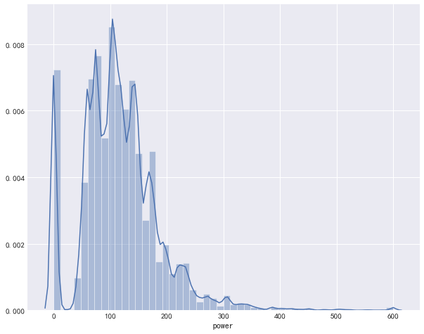

```python
# 可视化处理后'power'分布
plt.figure(figsize=(10, 8))
sns.distplot(df['power'])
plt.show()
```

#### 3.4.5 处理缺失值

```python
# 查看缺失值
df.isnull().sum()[df.isnull().sum() > 0]
```

```
bodyType              6010
fuelType             11604
gearbox               7949
model                    1
notRepairedDamage    32392
price                50000
dtype: int64
```

```python
# 用众数填充缺失值
df.fuelType.fillna(df.fuelType.mode()[0], inplace=True)
df.gearbox.fillna(df.gearbox.mode()[0], inplace=True)
df.bodyType.fillna(df.bodyType.mode()[0], inplace=True)
df.model.fillna(df.model.mode()[0], inplace=True)
df.notRepairedDamage.fillna(df.notRepairedDamage.mode()[0], inplace=True)
```

```python
df.isnull().sum()[df.isnull().sum() > 0]
```

```
price    50000
dtype: int64
```

df是由训练数据和测试数据合并而来，测试数据有50000个样本，预测特征是price，因此df中存在50000个缺失price特征的样本

#### 3.4.6 处理时间属性信息

```python
def date_process(x):
    year = int(str(x)[:4])
    month = int(str(x)[4:6])
    day = int(str(x)[6:8])

    if month < 1:
        month = 1

    date = datetime(year, month, day)
    return date
```

```python
df['regDates'] = df['regDate'].apply(date_process)
df['creatDates'] = df['creatDate'].apply(date_process)
df['regDate_year'] = df['regDates'].dt.year
df['regDate_month'] = df['regDates'].dt.month
df['regDate_day'] = df['regDates'].dt.day
df['creatDate_year'] = df['creatDates'].dt.year
df['creatDate_month'] = df['creatDates'].dt.month
df['creatDate_day'] = df['creatDates'].dt.day
```

```python
# 切割数据，导出数据
output_path = './process_data/'
print(df.shape)
train_num = df.shape[0] - 50000
df[:int(train_num)].to_csv(output_path + 'train_data_v1.csv', index=False, sep=' ')
df[train_num:train_num + 50000].to_csv(output_path + 'test_data_v1.csv', index=False, sep=' ')
```

```
(199999, 37)
```

## 4. 算法一的实验结果及可视化

### 4.1 算法说明

**数据集**

- [训练数据：data/train_data_v1.csv](https://github.com/Zening-Li/BIT_DataMining_project/tree/master/process_data)
- [测试数据：data/test_data_v1.csv](https://github.com/Zening-Li/BIT_DataMining_project/tree/master/process_data)
- [提交数据：output/submit.csv](https://github.com/ZedB/BIT-DataMining-project/blob/master/output)

**代码实现**

 algorithm1_final.ipynb

**说明**

### 4.2 可视化说明

**代码实现**

 见下方所示

**可视化过程**

### 4.3 实验代码及结果可视化

```python
import numpy as np
import pandas as pd
import seaborn as sns
import lightgbm as lgb
import matplotlib.pyplot as plt
from sklearn.ensemble import GradientBoostingRegressor
from sklearn.metrics import mean_squared_error, mean_absolute_error
from sklearn.linear_model import LinearRegression, Ridge, LassoCV
from sklearn.model_selection import train_test_split, GridSearchCV

%matplotlib inline
```

#### 读取预处理好的数据：

```python
# train_data = pd.read_csv('data/train_data_v1.csv', sep=' ')
# test_data = pd.read_csv('data/test_data_v1.csv', sep=' ')
train_data = pd.read_csv(r"C:\Users\shl\Desktop\train_data_v1.csv", sep=' ')
test_data = pd.read_csv(r"C:\Users\shl\Desktop\test_data_v1.csv", sep=' ')
print(train_data.shape)
print(test_data.shape)
```

```
(149999, 37)
(50000, 37)
```

#### 查看训练数据：

```python
train_data.head()
```

|  | SaleID | bodyType | brand | creatDate | fuelType | gearbox | kilometer | model | notRepairedDamage | power | ... | v_9 | name_count | regDates | creatDates | regDate_year | regDate_month | regDate_day | creatDate_year | creatDate_month | creatDate_day |
| --- | --- | --- | --- | --- | --- | --- | --- | --- | --- | --- | --- | --- | --- | --- | --- | --- | --- | --- | --- | --- | --- |
| 0 | 0 | 1.0 | 6 | 20160404 | 0.0 | 0.0 | 12.5 | 30.0 | 0.0 | 60 | ... | 0.097462 | 108 | 2004-04-02 | 2016-04-04 | 2004 | 4 | 2 | 2016 | 4 | 4 |
| 1 | 1 | 2.0 | 1 | 20160309 | 0.0 | 0.0 | 15.0 | 40.0 | 0.0 | 0 | ... | 0.020582 | 29 | 2003-03-01 | 2016-03-09 | 2003 | 3 | 1 | 2016 | 3 | 9 |
| 2 | 2 | 1.0 | 15 | 20160402 | 0.0 | 0.0 | 12.5 | 115.0 | 0.0 | 163 | ... | 0.027075 | 3 | 2004-04-03 | 2016-04-02 | 2004 | 4 | 3 | 2016 | 4 | 2 |
| 3 | 3 | 0.0 | 10 | 20160312 | 0.0 | 1.0 | 15.0 | 109.0 | 0.0 | 193 | ... | 0.000000 | 2 | 1996-09-08 | 2016-03-12 | 1996 | 9 | 8 | 2016 | 3 | 12 |
| 4 | 4 | 1.0 | 5 | 20160313 | 0.0 | 0.0 | 5.0 | 110.0 | 0.0 | 68 | ... | 0.121534 | 1 | 2012-01-03 | 2016-03-13 | 2012 | 1 | 3 | 2016 | 3 | 13 |

5 rows × 37 columns

#### 查看数据的统计信息：

```python
train_data.describe()
```

|  | SaleID | bodyType | brand | creatDate | fuelType | gearbox | kilometer | model | notRepairedDamage | power | ... | v_7 | v_8 | v_9 | name_count | regDate_year | regDate_month | regDate_day | creatDate_year | creatDate_month | creatDate_day |
| --- | --- | --- | --- | --- | --- | --- | --- | --- | --- | --- | --- | --- | --- | --- | --- | --- | --- | --- | --- | --- | --- |
| count | 149999.000000 | 149999.000000 | 149999.000000 | 1.499990e+05 | 149999.000000 | 149999.000000 | 149999.000000 | 149999.000000 | 149999.000000 | 149999.000000 | ... | 149999.000000 | 149999.000000 | 149999.000000 | 149999.000000 | 149999.000000 | 149999.000000 | 149999.000000 | 149999.000000 | 149999.000000 | 149999.000000 |
| mean | 74999.493837 | 1.738525 | 8.052727 | 2.016033e+07 | 0.354096 | 0.215975 | 12.597144 | 47.128581 | 0.095434 | 116.861752 | ... | 0.124693 | 0.058144 | 0.061995 | 16.621251 | 2003.357196 | 5.998393 | 6.502863 | 2015.999880 | 3.161581 | 15.833826 |
| std | 43301.558800 | 1.760784 | 7.864982 | 1.067332e+02 | 0.539748 | 0.411498 | 3.919584 | 49.536165 | 0.293814 | 70.074840 | ... | 0.201410 | 0.029185 | 0.035692 | 48.697958 | 5.362246 | 3.521590 | 3.450316 | 0.010954 | 0.380710 | 9.132285 |
| min | 0.000000 | 0.000000 | 0.000000 | 2.015062e+07 | 0.000000 | 0.000000 | 0.500000 | 0.000000 | 0.000000 | 0.000000 | ... | 0.000000 | 0.000000 | 0.000000 | 1.000000 | 1991.000000 | 1.000000 | 1.000000 | 2015.000000 | 1.000000 | 1.000000 |
| 25% | 37499.500000 | 0.000000 | 1.000000 | 2.016031e+07 | 0.000000 | 0.000000 | 12.500000 | 10.000000 | 0.000000 | 75.000000 | ... | 0.062474 | 0.035334 | 0.033930 | 1.000000 | 1999.000000 | 3.000000 | 4.000000 | 2016.000000 | 3.000000 | 8.000000 |
| 50% | 74999.000000 | 1.000000 | 6.000000 | 2.016032e+07 | 0.000000 | 0.000000 | 15.000000 | 30.000000 | 0.000000 | 110.000000 | ... | 0.095867 | 0.057014 | 0.058483 | 1.000000 | 2003.000000 | 6.000000 | 7.000000 | 2016.000000 | 3.000000 | 16.000000 |
| 75% | 112499.500000 | 3.000000 | 13.000000 | 2.016033e+07 | 1.000000 | 0.000000 | 15.000000 | 66.000000 | 0.000000 | 150.000000 | ... | 0.125243 | 0.079382 | 0.087489 | 7.000000 | 2007.000000 | 9.000000 | 9.000000 | 2016.000000 | 3.000000 | 24.000000 |
| max | 149999.000000 | 7.000000 | 39.000000 | 2.016041e+07 | 6.000000 | 1.000000 | 15.000000 | 247.000000 | 1.000000 | 600.000000 | ... | 1.404936 | 0.160791 | 0.222787 | 376.000000 | 2015.000000 | 12.000000 | 12.000000 | 2016.000000 | 12.000000 | 31.000000 |

8 rows × 35 columns

#### 提取所需特征列：

```python
numerical_cols = train_data.select_dtypes(exclude = 'object').columns
print(numerical_cols)
```

```
Index(['SaleID', 'bodyType', 'brand', 'creatDate', 'fuelType', 'gearbox',
       'kilometer', 'model', 'notRepairedDamage', 'power', 'price', 'regDate',
       'regionCode', 'v_0', 'v_1', 'v_10', 'v_11', 'v_12', 'v_13', 'v_14',
       'v_2', 'v_3', 'v_4', 'v_5', 'v_6', 'v_7', 'v_8', 'v_9', 'name_count',
       'regDate_year', 'regDate_month', 'regDate_day', 'creatDate_year',
       'creatDate_month', 'creatDate_day'],
      dtype='object')
```

```python
feature_cols = [x for x in train_data.columns if x not in ['SaleID','name','regDates','creatDates','price','model','brand','regionCode','creatDate']]
```

#### 构建数据集并进行划分（Train, Val）：

```python
train_X = train_data[feature_cols]
test_X = test_data[feature_cols]
train_Y = train_data['price']
```

```python
print('X train shape:',train_X.shape)
print('X test shape:',test_X.shape)
print('Y train shape:',train_Y.shape)
```

```
X train shape: (149999, 29)
X test shape: (50000, 29)
Y train shape: (149999,)
```

```python
x_train, x_val, y_train, y_val = train_test_split(train_X, train_Y, test_size=0.3)
```

#### 通过五种模型进行训练，并用MAE评价标准进行比较：

```python
# 线性回归
model_1 = LinearRegression()
model_1.fit(x_train, y_train)
pred_1 = model_1.predict(x_val)
mae_1 = mean_absolute_error(y_val, pred_1)
print('MAE = ', mae_1)
```

```
MAE =  0.1941119709880854
```

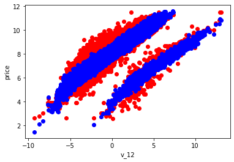

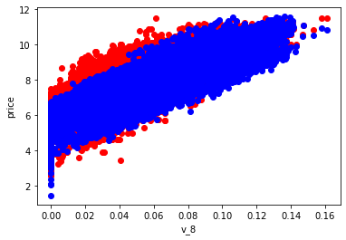

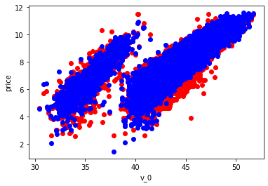

```python
# 可视化预测结果
# 由于'v_12' ,'v_8', 'v_0'与price相关度较高所以进行可视化观察
for i in ['v_12' ,'v_8', 'v_0']:
    plt.scatter(x_val[i], y_val, color='red')
    plt.scatter(x_val[i], pred_1, color='blue')
    plt.xlabel(i)
    plt.ylabel('price')
    plt.show()
```

```python
# 岭回归
model_2 = Ridge(alpha=0.8)
model_2.fit(x_train, y_train)
pred_2 = model_2.predict(x_val)
mae_2 = mean_absolute_error(y_val, pred_2)
print('MAE = ', mae_2)
```

```
MAE =  0.19768918894059345
```

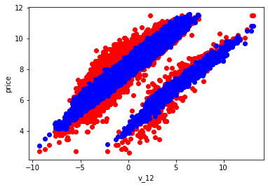

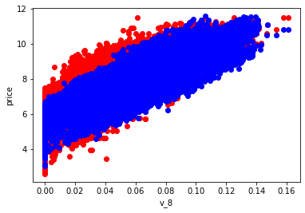

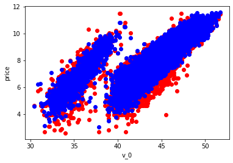

```python
# 可视化预测结果
# 由于'v_12' ,'v_8', 'v_0'与price相关度较高所以进行可视化观察
for i in ['v_12' ,'v_8', 'v_0']:
    plt.scatter(x_val[i], y_val, color='red')
    plt.scatter(x_val[i], pred_2, color='blue')
    plt.xlabel(i)
    plt.ylabel('price')
    plt.show()
```

```python
# Lasso回归
model_3 = LassoCV()
model_3.fit(x_train, y_train)
pred_3 = model_3.predict(x_val)
mae_3 = mean_absolute_error(y_val, pred_3)
print('MAE = ', mae_3)
```

```
MAE =  0.603703436321199
```

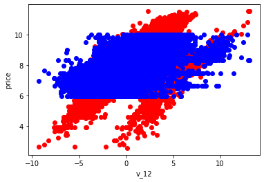

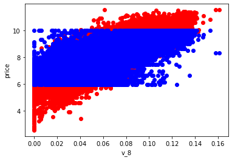

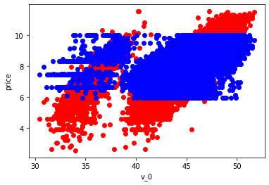

```python
# 可视化预测结果
# 由于'v_12' ,'v_8', 'v_0'与price相关度较高所以进行可视化观察
for i in ['v_12' ,'v_8', 'v_0']:
    plt.scatter(x_val[i], y_val, color='red')
    plt.scatter(x_val[i], pred_3, color='blue')
    plt.xlabel(i)
    plt.ylabel('price')
    plt.show()
```

从可视化中可以看出Lasso回归的预测price值全是中间值，高price和低price很少。可能是由于该方法是一种压缩估计，压缩了一些回归系数，得到的是一个较为精炼的模型。从MAE值也可以看出，Lasso回归是最高的。

```python
# GDBT
gdbt = GradientBoostingRegressor()
gdbt.fit(x_train, y_train)
pred_4 = gdbt.predict(x_val)
mae_4 = mean_absolute_error(y_val, pred_4)
print('MAE = ', mae_4)
```

```
MAE =  0.17660262801012233
```

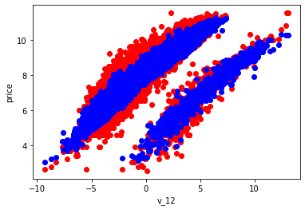

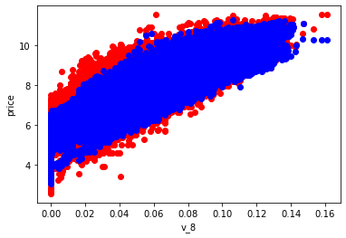

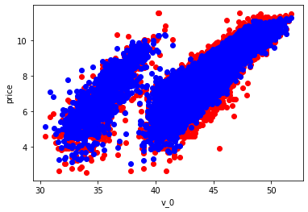

```python
# 可视化预测结果
# 由于'v_12' ,'v_8', 'v_0'与price相关度较高所以进行可视化观察
for i in ['v_12' ,'v_8', 'v_0']:
    plt.scatter(x_val[i], y_val, color='red')
    plt.scatter(x_val[i], pred_4, color='blue')
    plt.xlabel(i)
    plt.ylabel('price')
    plt.show()
```

```python
# LightGBM
estimator = lgb.LGBMRegressor(num_leaves=63, n_estimators=100)
param_grid = {
    'learning_rate': [0.01, 0.05, 0.1],
    }
gbm = GridSearchCV(estimator, param_grid)
gbm.fit(x_train, y_train)
pred_5 = gbm.predict(x_val)
mae_5 = mean_absolute_error(y_val, pred_5)
print('MAE = ', mae_5)
```

```
MAE =  0.1371255612762281
```

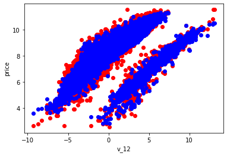

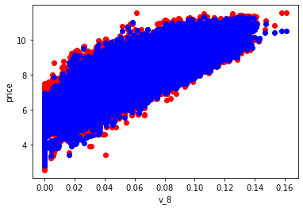

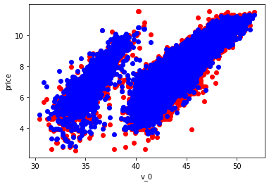

```python
# 可视化预测结果
# 由于'v_12' ,'v_8', 'v_0'与price相关度较高所以进行可视化观察
for i in ['v_12' ,'v_8', 'v_0']:
    plt.scatter(x_val[i], y_val, color='red')
    plt.scatter(x_val[i], pred_5, color='blue')
    plt.xlabel(i)
    plt.ylabel('price')
    plt.show()
```

LightGBM算法MAE值最小，即效果最好。从可视化也可以看出其预测结果很好。对于v_12属性，其他算法效果都不是很好，LightGBM算法则很好。

##### 通过对比可知，LightGBM训练得到的模型效果更好，故我们采用LightGBM训练模型并进行预测。

#### 采用LightGBM模型在原始数据集上进行预测：

```python
estimator = lgb.LGBMRegressor(num_leaves=63, n_estimators=100)
param_grid = {
    'learning_rate': [0.01, 0.05, 0.1],
    }
pred_model = GridSearchCV(estimator, param_grid)
pred_model.fit(train_X, train_Y)
price = pred_model.predict(test_X)
```

#### 将预测值生成指定格式的csv文件：

```python
submit = pd.DataFrame()
submit['SaleID'] = test_data.SaleID
submit['price'] = price
submit.to_csv('output/submit.csv',index=False)
```

```python
submit.head(10)
```

|  | SaleID | price |
| --- | --- | --- |
| 0 | 200000 | 7.146314 |
| 1 | 200001 | 7.548770 |
| 2 | 200002 | 8.888396 |
| 3 | 200003 | 7.084090 |
| 4 | 200004 | 7.582857 |
| 5 | 200005 | 7.127663 |
| 6 | 200006 | 5.990862 |
| 7 | 200007 | 8.110016 |
| 8 | 200008 | 9.461447 |
| 9 | 200009 | 6.423404 |

## 5. 算法二的实验结果及可视化

### 5.1 算法说明

**数据集**

- [训练数据：data/train_data_v1.csv](https://github.com/Zening-Li/BIT_DataMining_project/tree/master/process_data)
- [测试数据：data/test_data_v1.csv](https://github.com/Zening-Li/BIT_DataMining_project/tree/master/process_data)
- [提交数据：output/submit.csv](https://github.com/ZedB/BIT-DataMining-project/blob/master/output)
- [输出数据：output/algo2_predict.csv](https://github.com/liucc1997/DMC/blob/master/DataMining_project/output/algo2_predict.csv)

**代码实现**

 algorithm2.ipynb

**说明**

- 使用回归决策树模型
- 训练集中，根据creatDates和creatDates计算得到used_time
- 作为特征的属性包括:

### 5.2 可视化说明

**代码实现**

如下方所示

**可视化过程**

### 5.3 实验代码及结果可视化

#### 载入数据

```python
import matplotlib
import numpy as np
import pandas as pd
%matplotlib inline
from matplotlib import pyplot as plt
from sklearn import tree
from sklearn.model_selection import train_test_split
from sklearn.metrics import mean_absolute_error
from sklearn.preprocessing import StandardScaler
from xgboost.sklearn import XGBRegressor
from sklearn.ensemble import RandomForestRegressor
import joblib
```

读入经过预处理的数据

```python
train_path = "data/train_data_v1.csv"
train_data = pd.read_csv(train_path,sep=" ")
test_path = "data/test_data_v1.csv"
test_data = pd.read_csv(test_path,sep=" ")
data = train_data.copy(deep=True)
```

#### 特征选择

选择作为特征的属性如choosed_attris所列出，根据检验推测二手车的使用时间与其价格应该成反比，所以计算regdate和createdate的差得到车辆的使用时间，也作为其中一个特征。

```python
data['used_time'] = (pd.to_datetime(data['creatDates'], format='%Y-%m-%d', errors='coerce') -
                            pd.to_datetime(data['regDates'], format='%Y-%m-%d', errors='coerce')).dt.days
choosed_attris = ["bodyType","brand","kilometer",
              'model', 'notRepairedDamage', 'power',
              'v_0', 'v_1', 'v_10', 'v_11', 'v_12', 'v_13', 'v_14',
               'v_2', 'v_3', 'v_4', 'v_5', 'v_6', 'v_7', 'v_8', 'v_9',
              'regDate_year',
              'name_count','used_time']
train = data[choosed_attris]
label = data["price"]
```

```python
train
```

|  | bodyType | brand | kilometer | model | notRepairedDamage | power | v_0 | v_1 | v_10 | v_11 | ... | v_3 | v_4 | v_5 | v_6 | v_7 | v_8 | v_9 | regDate_year | name_count | used_time |
| --- | --- | --- | --- | --- | --- | --- | --- | --- | --- | --- | --- | --- | --- | --- | --- | --- | --- | --- | --- | --- | --- |
| 0 | 1.0 | 6 | 12.5 | 30.0 | 0.0 | 60 | 43.357796 | 3.966344 | -2.881803 | 2.804097 | ... | 2.159744 | 1.143786 | 0.235676 | 0.101988 | 0.129549 | 0.022816 | 0.097462 | 2004 | 108 | 4385 |
| 1 | 2.0 | 1 | 15.0 | 40.0 | 0.0 | 0 | 45.305273 | 5.236112 | -4.900482 | 2.096338 | ... | 1.380657 | -1.422165 | 0.264777 | 0.121004 | 0.135731 | 0.026597 | 0.020582 | 2003 | 29 | 4757 |
| 2 | 1.0 | 15 | 12.5 | 115.0 | 0.0 | 163 | 45.978359 | 4.823792 | -4.846749 | 1.803559 | ... | -0.998467 | -0.996911 | 0.251410 | 0.114912 | 0.165147 | 0.062173 | 0.027075 | 2004 | 3 | 4382 |
| 3 | 0.0 | 10 | 15.0 | 109.0 | 0.0 | 193 | 45.687478 | 4.492574 | -4.509599 | 1.285940 | ... | 0.883600 | -2.228079 | 0.274293 | 0.110300 | 0.121964 | 0.033395 | 0.000000 | 1996 | 2 | 7125 |
| 4 | 1.0 | 5 | 5.0 | 110.0 | 0.0 | 68 | 44.383511 | 2.031433 | -1.896240 | 0.910783 | ... | -1.571239 | 2.246088 | 0.228036 | 0.073205 | 0.091880 | 0.078819 | 0.121534 | 2012 | 1 | 1531 |
| ... | ... | ... | ... | ... | ... | ... | ... | ... | ... | ... | ... | ... | ... | ... | ... | ... | ... | ... | ... | ... | ... |
| 149994 | 4.0 | 10 | 15.0 | 121.0 | 0.0 | 163 | 45.316543 | -3.139095 | 1.988114 | -2.983973 | ... | -0.736609 | -1.505820 | 0.280264 | 0.000310 | 0.048441 | 0.071158 | 0.019174 | 2000 | 1 | 5772 |
| 149995 | 0.0 | 11 | 10.0 | 116.0 | 0.0 | 125 | 45.972058 | -3.143764 | 1.839166 | -2.774615 | ... | -2.366699 | 0.698012 | 0.253217 | 0.000777 | 0.084079 | 0.099681 | 0.079371 | 2009 | 1 | 2322 |
| 149996 | 1.0 | 11 | 6.0 | 60.0 | 0.0 | 90 | 44.733481 | -3.105721 | 2.439812 | -1.630677 | ... | -2.279091 | 1.423661 | 0.233353 | 0.000705 | 0.118872 | 0.100118 | 0.097914 | 2010 | 1 | 2003 |
| 149997 | 3.0 | 10 | 15.0 | 34.0 | 0.0 | 156 | 45.658634 | -3.204785 | 2.075380 | -2.633719 | ... | -1.179812 | 0.620680 | 0.256369 | 0.000252 | 0.081479 | 0.083558 | 0.081498 | 2006 | 1 | 3673 |
| 149998 | 6.0 | 28 | 12.5 | 19.0 | 0.0 | 193 | 45.536383 | -3.200326 | 1.978453 | -3.179913 | ... | -0.067144 | -1.396166 | 0.284475 | 0.000000 | 0.040072 | 0.062543 | 0.025819 | 1999 | 1 | 6239 |

149999 rows × 24 columns

```python
label
```

```
0         7.523481
1         8.188967
2         8.736007
3         7.783641
4         8.556606
            ...
149994    8.682877
149995    9.159152
149996    8.922792
149997    8.517193
149998    8.455531
Name: price, Length: 149999, dtype: float64
```

将构建好的数据集划分为训练集<x_train, y_train>和验证集<x_train, y_train>两部分，并将划分前后的这些数据全部转储到文件中。

```python
x_train, x_test, y_train, y_test = train_test_split(train, label, test_size=0.2)
joblib.dump(train, "dataset/train.csv")
joblib.dump(label, "dataset/label.csv")
joblib.dump(x_train, "dataset/x_train.csv")
joblib.dump(x_test, "dataset/x_test.csv")
joblib.dump(y_train, "dataset/y_train.csv")
joblib.dump(y_test, "dataset/y_test.csv")
```

```
['dataset/y_test.csv']
```